# Comparing Copy Number Calling Methods: GMM vs HMM on Tapestri Data

Dong Pei

2026-03-07

## Introduction

Single-cell DNA sequencing with the Tapestri platform enables copy number (CN) profiling at single-cell resolution. Two complementary approaches exist for calling integer copy number from Tapestri data:

- **GMM (Gaussian Mixture Model)** via the `karyotapR` package, which fits mixture models to normalized read depth at the chromosome level.
- **HMM (Hidden Markov Model)** via the `scPloidyR` package, which jointly models read depth and B-allele frequency (BAF) along amplicons within each chromosome.

This tutorial walks through both methods on the same Tapestri cell-mixture experiment and compares their results side by side.

## Setup

Load the required libraries and set a seed for reproducibility.

```r
library(karyotapR)
library(forcats)
library(SummarizedExperiment)
library(SingleCellExperiment)
library(scPloidyR)

set.seed(2023)
```

## Data Download

This guide uses the cell mixture experiment from the KaryoTap publication (Mays, 2023). The Tapestri Pipeline `.h5` output file is available on Zenodo and can be downloaded by `curl::curl_download()` or directly from the website.

```r
curl::curl_download(
  url = "https://zenodo.org/record/8305841/files/tapestri-experiment01-panelv1.h5?download=1",
  destfile = "./tap-cellmixture.h5",
  quiet = FALSE
)
```

## Data Import

We import the Tapestri HDF5 file using `createTapestriExperiment()`. The dataset is a cell-mixture experiment containing multiple cell lines with known karyotypic differences.

```r
cellmix <- createTapestriExperiment("../data/tap-cellmixture.h5", panel.id = "CO261")
cellmix
```

```
## class: TapestriExperiment
## dim: 330 3555
## metadata(7): sample.name pipeline.panel.name ... date.h5.created
##   mean.reads.per.cell.per.probe
## assays(1): counts
## rownames(330): AMPL158802 AMPL146998 ... AMPL162086 AMPL161738
## rowData names(8): probe.id chr ... cytoband arm
## colnames(3555): AACAACCTAATAGTGGTT-1 AACAACCTAGTCCTAGTT-1 ...
##   TTGTAATGCTCGTACCTT-1 TTGTATCACACTTGATCT-1
## colData names(2): cell.barcode total.reads
## reducedDimNames(0):
## mainExpName: CNV
## altExpNames(1): alleleFrequency
## barcodeProbe: not specified
## grnaProbe: not specified
## gmmParams(0):
```

Inspect the cell-level and probe-level metadata:

```r
head(colData(cellmix))
```

```
## DataFrame with 6 rows and 2 columns
##                              cell.barcode total.reads
##                               <character>   <numeric>
## AACAACCTAATAGTGGTT-1 AACAACCTAATAGTGGTT-1       60264
## AACAACCTAGTCCTAGTT-1 AACAACCTAGTCCTAGTT-1       22455
## AACAACCTATGGACGAGA-1 AACAACCTATGGACGAGA-1       51206
## AACAACTGGCGCACTCTT-1 AACAACTGGCGCACTCTT-1       29616
## AACAACTGGGACATAACG-1 AACAACTGGGACATAACG-1       17998
## AACAACTGGGGAACCTAG-1 AACAACTGGGGAACCTAG-1       14202
```

```r
head(rowData(cellmix))
```

```
## DataFrame with 6 rows and 8 columns
##               probe.id      chr start.pos   end.pos total.reads median.reads
##            <character> <factor> <numeric> <numeric>   <numeric>    <integer>
## AMPL158802  AMPL158802        1   1479191   1479385      202832           49
## AMPL146998  AMPL146998        1   6196653   6196900      112408           24
## AMPL158817  AMPL158817        1  11832076  11832330       99472           22
## AMPL158827  AMPL158827        1  17087135  17087388     1162986          304
## AMPL158845  AMPL158845        1  24412922  24413191        1008            0
## AMPL147006  AMPL147006        1  34285091  34285360      248023           53
##               cytoband      arm
##            <character> <factor>
## AMPL158802      p36.33       1p
## AMPL146998      p36.31       1p
## AMPL158817      p36.22       1p
## AMPL158827      p36.13       1p
## AMPL158845      p36.11       1p
## AMPL147006       p35.1       1p
```

## Allele Frequency Clustering

Before calling copy number, we cluster cells by their allele frequency profiles. This identifies distinct cell lines in the mixture. We run PCA, project into UMAP space, and apply density-based clustering (dbscan).

```r
cellmix <- runPCA(cellmix)
cellmix <- runUMAP(cellmix, pca.dims = 1:4)
cellmix <- runClustering(cellmix, eps = 0.9)
```

Subset to the five main clusters (removing doublets) and assign descriptive labels:

```r
cellmix.subset <- cellmix[, colData(cellmix)$cluster %in% 1:5]

colData(cellmix.subset)$cluster <-
  forcats::fct_recode(colData(cellmix.subset)$cluster,
                      cellline1 = "1",
                      cellline2 = "2",
                      cellline3 = "3",
                      cellline4 = "4",
                      cellline5 = "5")

forcats::fct_count(colData(cellmix.subset)$cluster)
```

```
## # A tibble: 11 × 2
##    f             n
##    <fct>     <int>
##  1 cellline1   987
##  2 cellline2   591
##  3 cellline3   575
##  4 cellline4   469
##  5 cellline5   398
##  6 6             0
##  7 7             0
##  8 8             0
##  9 9             0
## 10 10            0
## 11 11            0
```

## Data Preprocessing

Both methods share the same preprocessing steps: normalizing read counts and removing problematic probes.

```r
cellmix.subset <- calcNormCounts(cellmix.subset)
```

Generate a control copy number template. We use `cellline3` as the reference cell line with a baseline copy number of 2. RPE1 cells carry a known trisomy 10q, so we adjust that arm to CN=3.

```r
control.copy.number <-
  generateControlCopyNumberTemplate(cellmix.subset,
                                    sample.feature.label = "cellline3",
                                    copy.number = 2)

control.copy.number["10q", "copy.number"] <- 3
control.copy.number
```

```
##     arm copy.number sample.label
## 1p   1p           2    cellline3
## 1q   1q           2    cellline3
## 2p   2p           2    cellline3
## 2q   2q           2    cellline3
## 3p   3p           2    cellline3
## 3q   3q           2    cellline3
## 4p   4p           2    cellline3
## 4q   4q           2    cellline3
## 5p   5p           2    cellline3
## 5q   5q           2    cellline3
## 6p   6p           2    cellline3
## 6q   6q           2    cellline3
## 7p   7p           2    cellline3
## 7q   7q           2    cellline3
## 8p   8p           2    cellline3
## 8q   8q           2    cellline3
## 9p   9p           2    cellline3
## 9q   9q           2    cellline3
## 10p 10p           2    cellline3
## 10q 10q           3    cellline3
## 11p 11p           2    cellline3
## 11q 11q           2    cellline3
## 12p 12p           2    cellline3
## 12q 12q           2    cellline3
## 13q 13q           2    cellline3
## 14q 14q           2    cellline3
## 15q 15q           2    cellline3
## 16p 16p           2    cellline3
## 16q 16q           2    cellline3
## 17p 17p           2    cellline3
## 17q 17q           2    cellline3
## 18p 18p           2    cellline3
## 18q 18q           2    cellline3
## 19p 19p           2    cellline3
## 19q 19q           2    cellline3
## 20p 20p           2    cellline3
## 20q 20q           2    cellline3
## 21q 21q           2    cellline3
## 22q 22q           2    cellline3
## Xp   Xp           2    cellline3
## Xq   Xq           2    cellline3
```

Remove probes with zero or near-zero median counts in the reference, which produce unreliable normalized values:

```r
probes.to.remove <- c("AMPL158845", "AMPL147043", "AMPL147154",
                      "AMPL159975", "AMPL147293", "AMPL113086",
                      "AMPL147323", "AMPL158390", "AMPL158655",
                      "AMPL135088", "AMPL159339")
cellmix.subset <- cellmix.subset[!rowData(cellmix.subset)$probe.id %in% probes.to.remove, ]

cat("Remaining probes:", nrow(cellmix.subset), "\n")
```

```
## Remaining probes: 319
```

## Copy Number Calling: GMM (karyotapR)

The GMM approach fits Gaussian mixture models to chromosome-level smoothed copy number values. First we calculate raw and smoothed copy number estimates, then apply the GMM to assign integer states.

```r
cellmix.subset <- calcCopyNumber(cellmix.subset,
                                 control.copy.number = control.copy.number,
                                 sample.feature = "cluster")

cellmix.subset <- calcSmoothCopyNumber(cellmix.subset)
```

```r
reference.bcs <- colData(cellmix.subset)$cell.barcode[
  colData(cellmix.subset)$cluster == "cellline2"
]

cellmix.subset <- calcGMMCopyNumber(cellmix.subset,
                                    cell.barcodes = reference.bcs,
                                    control.copy.number = control.copy.number,
                                    model.components = 1:5)
```

Visualize the GMM copy number calls as a heatmap:

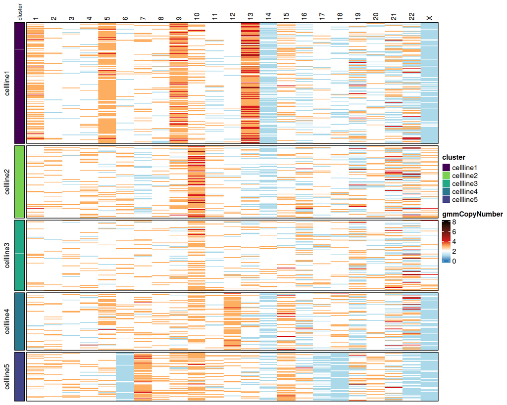

```r
assayHeatmap(cellmix.subset,
             alt.exp = "smoothedCopyNumberByChr",
             assay = "gmmCopyNumber",
             split.row.by = "cluster",
             annotate.row.by = "cluster",
             color.preset = "copy.number",
             cluster_rows = FALSE)
```

## Copy Number Calling: HMM (scPloidyR)

The HMM approach models amplicon-level read depth jointly with B-allele frequency. It uses the Viterbi algorithm to find the most likely sequence of CN states along each chromosome.

### Extract Depth and BAF Data

We extract the normalized depth matrix and build a BAF data structure by mapping variants from the `alleleFrequency` alternative experiment back to their parent amplicons.

```r
depth_matrix <- as.matrix(assay(cellmix.subset, "normcounts"))
amplicon_ids <- rowData(cellmix.subset)$probe.id
amplicon_chr_labels <- rowData(cellmix.subset)$chr

n_cells <- ncol(depth_matrix)
n_amplicons <- nrow(depth_matrix)

cat("Depth matrix:", n_amplicons, "amplicons x", n_cells, "cells\n")
```

```
## Depth matrix: 319 amplicons x 3020 cells
```

```r
# Extract allele frequency data
af_altexp <- altExp(cellmix.subset, "alleleFrequency")
af_matrix <- assay(af_altexp, "alleleFrequency")
variant_rowdata <- rowData(af_altexp)

# Identify chromosome and position columns
variant_chr <- variant_rowdata[["CHROM"]]
variant_pos <- variant_rowdata[["POS"]]

# Get amplicon coordinates
amplicon_rowdata <- rowData(cellmix.subset)
amplicon_start <- amplicon_rowdata$start.pos
amplicon_end <- amplicon_rowdata$end.pos
amplicon_chr <- amplicon_rowdata$chr

# Map each variant to its enclosing amplicon
n_variants <- nrow(af_matrix)
variant_to_amplicon <- integer(n_variants)

for (v_idx in seq_len(n_variants)) {
  v_chr <- as.character(variant_chr[v_idx])
  v_pos <- as.numeric(variant_pos[v_idx])
  matching_amp <- which(
    as.character(amplicon_chr) == v_chr &
    amplicon_start <= v_pos &
    amplicon_end >= v_pos
  )
  variant_to_amplicon[v_idx] <- if (length(matching_amp) >= 1) matching_amp[1] else NA_integer_
}

n_mapped <- sum(!is.na(variant_to_amplicon))
cat(sprintf("Variants mapped: %d / %d (%.1f%%)\n",
            n_mapped, n_variants, 100 * n_mapped / n_variants))
```

```
## Variants mapped: 0 / 584 (0.0%)
```

Build the BAF list structure expected by `scPloidyR`: a list of cells, each containing a list of amplicons with their BAF values.

```r
baf_list <- lapply(seq_len(n_cells), function(cell_idx) {
  amplicon_bafs <- vector("list", n_amplicons)
  for (amp_idx in seq_len(n_amplicons)) {
    amplicon_bafs[[amp_idx]] <- numeric(0)
  }
  for (v_idx in seq_len(n_variants)) {
    amp_idx <- variant_to_amplicon[v_idx]
    if (!is.na(amp_idx)) {
      baf_value <- af_matrix[v_idx, cell_idx]
      if (!is.na(baf_value) && is.finite(baf_value)) {
        baf_value <- max(0, min(1, baf_value))
        amplicon_bafs[[amp_idx]] <- c(amplicon_bafs[[amp_idx]], baf_value)
      }
    }
  }
  amplicon_bafs
})
```

### Identify Reference Cells and Run HMM

We use the same reference cluster (`cellline2`) as in the GMM analysis. The `reference_cn` parameter accounts for the known trisomy 10 in RPE1 cells.

```r
reference_cell_indices <- which(colData(cellmix.subset)$cluster == "cellline2")
reference_cn <- c("10" = 3)

cat("Reference cells:", length(reference_cell_indices), "\n")
```

```
## Reference cells: 591
```

```r
hmm_results <- call_copy_number(
  depth_matrix = depth_matrix,
  baf_data = baf_list,
  amplicon_chr_labels = amplicon_chr_labels,
  reference_cell_indices = reference_cell_indices,
  reference_cn = reference_cn,
  states = 1:5,
  ncores = 1,
  progress = TRUE
)
```

```
## Starting parallel per-chromosome HMM analysis for 3020 cells across 319 amplicons
## Using 1 CPU cores for parallel processing
## Learning reference parameters from 591 reference cells...
```

```
## Using mclapply (fork-based parallelism)
##   Progress: 10% (302 / 3020 cells)
##   Progress: 20% (604 / 3020 cells)
##   Progress: 30% (906 / 3020 cells)
##   Progress: 40% (1208 / 3020 cells)
##   Progress: 50% (1510 / 3020 cells)
##   Progress: 60% (1812 / 3020 cells)
##   Progress: 70% (2114 / 3020 cells)
##   Progress: 80% (2416 / 3020 cells)
##   Progress: 90% (2718 / 3020 cells)
##   Progress: 100% (3020 / 3020 cells)
##
## Parallel per-chromosome HMM analysis complete!
##   Total time: 849.18 seconds
##   Mean time per cell: 0.281 seconds
##   Speedup estimate: 0.8x (vs sequential)
##   Successful: 3020 / 3020 cells
##   Mean convergence rate: 100.0% (23/23 chromosomes x 3020 cells)
```

```r
cat("HMM analysis complete.\n")
```

```
## HMM analysis complete.
```

```r
cat("Timing:", round(hmm_results$timing$total_time, 1), "seconds\n")
```

```
## Timing: 849.2 seconds
```

```r
cat("Convergence rate:",
    round(hmm_results$convergence_summary$mean_convergence_rate * 100, 1), "%\n")
```

```
## Convergence rate: 100 %
```

### Store and Aggregate HMM Results

Store amplicon-level CN calls in the experiment object and aggregate to chromosome level using the modal CN per chromosome.

```r
assay(cellmix.subset, "copyNumber.HMM") <- hmm_results$cn_calls_amplicon
```

```r
chr_info <- rowData(cellmix.subset)$chr
cn_amplicon <- assay(cellmix.subset, "copyNumber.HMM")

# Sort chromosomes naturally
chromosomes <- unique(chr_info)
chr_numeric <- suppressWarnings(as.numeric(gsub("chr", "", chromosomes, ignore.case = TRUE)))
chr_order <- order(is.na(chr_numeric), chr_numeric, chromosomes)
chromosomes <- chromosomes[chr_order]

# Aggregate by mode
cn_by_chr <- matrix(NA_integer_,
                    nrow = length(chromosomes),
                    ncol = ncol(cellmix.subset),
                    dimnames = list(chromosomes, colnames(cellmix.subset)))

get_mode <- function(x) {
  x <- x[!is.na(x)]
  if (length(x) == 0) return(NA_integer_)
  ux <- unique(x)
  ux[which.max(tabulate(match(x, ux)))]
}

for (chr in chromosomes) {
  chr_idx <- which(chr_info == chr)
  if (length(chr_idx) > 0) {
    cn_by_chr[chr, ] <- apply(cn_amplicon[chr_idx, , drop = FALSE], 2, get_mode)
  }
}

# Store as altExp
chr_se <- SummarizedExperiment(
  assays = list(hmmCopyNumber = cn_by_chr),
  rowData = DataFrame(chr = chromosomes, row.names = chromosomes),
  colData = colData(cellmix.subset)
)
altExp(cellmix.subset, "hmmCopyNumberByChr") <- chr_se

cat("Aggregated", nrow(cn_amplicon), "amplicons to", length(chromosomes), "chromosomes\n")
```

```
## Aggregated 319 amplicons to 23 chromosomes
```

Visualize the HMM copy number calls:

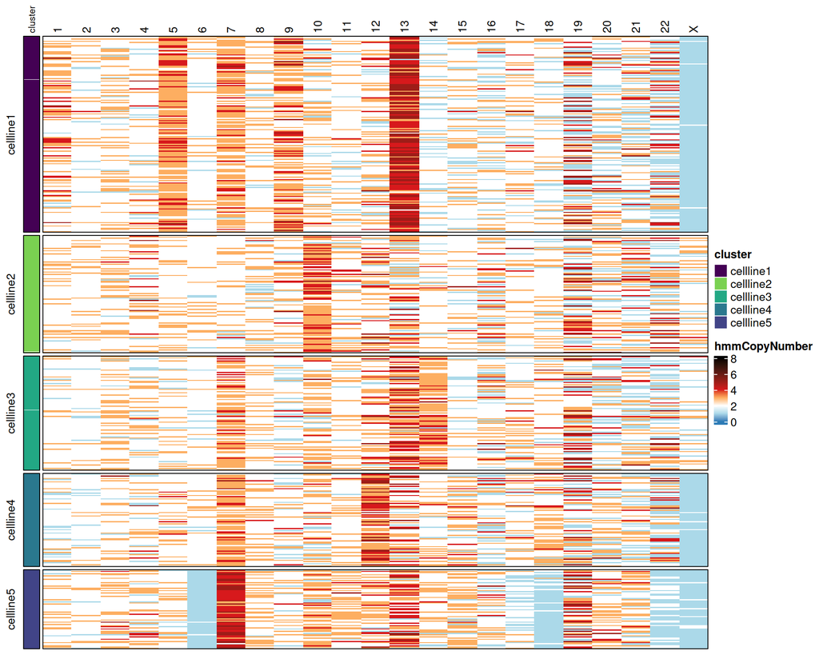

```r
assayHeatmap(cellmix.subset,
             alt.exp = "hmmCopyNumberByChr",
             assay = "hmmCopyNumber",
             split.row.by = "cluster",
             annotate.row.by = "cluster",
             color.preset = "copy.number",
             cluster_rows = FALSE)
```

## Comparing GMM and HMM Results

### Side-by-Side Heatmaps

We draw both heatmaps together for direct visual comparison. Panel (A) shows GMM results, panel (B) shows HMM results.

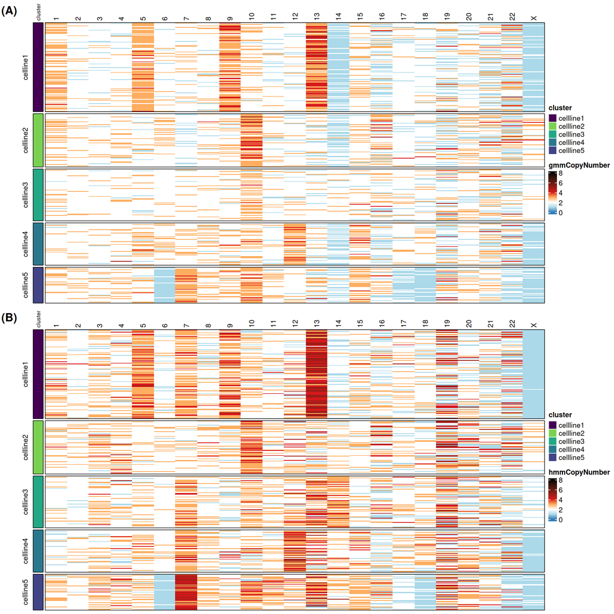

```r
gmm_hm <- assayHeatmap(cellmix.subset,
                        alt.exp = "smoothedCopyNumberByChr",
                        assay = "gmmCopyNumber",
                        split.row.by = "cluster",
                        annotate.row.by = "cluster",
                        color.preset = "copy.number",
                        cluster_rows = FALSE)

hmm_hm <- assayHeatmap(cellmix.subset,
                        alt.exp = "hmmCopyNumberByChr",
                        assay = "hmmCopyNumber",
                        split.row.by = "cluster",
                        annotate.row.by = "cluster",
                        color.preset = "copy.number",
                        cluster_rows = FALSE)

# Panel A: GMM
grid::pushViewport(grid::viewport(x = 0, y = 0.5, width = 0.03, height = 0.5,
                                  just = c("left", "bottom")))
grid::grid.text("(A)", x = 0.5, y = 0.98,
                gp = grid::gpar(fontsize = 16, fontface = "bold"),
                just = c("center", "top"))
grid::popViewport()
grid::pushViewport(grid::viewport(x = 0.03, y = 0.5, width = 0.97, height = 0.5,
                                  just = c("left", "bottom")))
ComplexHeatmap::draw(gmm_hm, newpage = FALSE)
grid::popViewport()

# Panel B: HMM
grid::pushViewport(grid::viewport(x = 0, y = 0, width = 0.03, height = 0.5,
                                  just = c("left", "bottom")))
grid::grid.text("(B)", x = 0.5, y = 0.98,
                gp = grid::gpar(fontsize = 16, fontface = "bold"),
                just = c("center", "top"))
grid::popViewport()
grid::pushViewport(grid::viewport(x = 0.03, y = 0, width = 0.97, height = 0.5,
                                  just = c("left", "bottom")))
ComplexHeatmap::draw(hmm_hm, newpage = FALSE)
grid::popViewport()
```

### Chromosome-Level Prediction Comparison

We extract the chromosome-level CN predictions from both methods and compare them quantitatively across all cells.

```r
# Extract chromosome-level matrices
gmm_chr_matrix <- assay(altExp(cellmix.subset, "smoothedCopyNumberByChr"), "gmmCopyNumber")
hmm_chr_matrix <- assay(altExp(cellmix.subset, "hmmCopyNumberByChr"), "hmmCopyNumber")

# Find common chromosomes
common_chr <- intersect(rownames(gmm_chr_matrix), rownames(hmm_chr_matrix))

gmm_common <- gmm_chr_matrix[common_chr, ]
hmm_common <- hmm_chr_matrix[common_chr, ]

# Overall agreement
total_entries <- length(gmm_common)
matching <- sum(gmm_common == hmm_common, na.rm = TRUE)
agreement_pct <- 100 * matching / total_entries

cat(sprintf("Overall agreement: %.1f%% (%d / %d chromosome-cell entries)\n",
            agreement_pct, matching, total_entries))
```

[output not shown]

Per-chromosome agreement between the two methods:

```r
chr_agreement <- sapply(common_chr, function(chr) {
  g <- gmm_common[chr, ]
  h <- hmm_common[chr, ]
  100 * sum(g == h, na.rm = TRUE) / length(g)
})

agreement_df <- data.frame(
  Chromosome = common_chr,
  Agreement_Pct = round(chr_agreement, 1)
)
agreement_df[order(agreement_df$Agreement_Pct), ]
```

```
##    Chromosome Agreement_Pct
## 13         13          31.5
## 7           7          32.3
## 14         14          36.5
## 19         19          43.3
## 12         12          60.1
## 20         20          60.5
## 10         10          61.4
## 16         16          65.0
## 3           3          68.6
## 4           4          69.1
## 22         22          69.8
## 21         21          70.2
## 17         17          70.6
## 9           9          70.7
## 5           5          71.6
## 18         18          74.9
## 1           1          75.0
## 11         11          75.3
## 15         15          75.8
## 8           8          78.4
## X           X          84.7
## 2           2          85.6
## 6           6          87.4
```

### Per-Cluster Agreement

```r
clusters <- colData(cellmix.subset)$cluster
cluster_levels <- levels(clusters)

for (cl in cluster_levels) {
  cl_idx <- which(clusters == cl)
  g <- gmm_common[, cl_idx]
  h <- hmm_common[, cl_idx]
  pct <- 100 * sum(g == h, na.rm = TRUE) / length(g)
  cat(sprintf("  %s: %.1f%% agreement (%d cells)\n", cl, pct, length(cl_idx)))
}
```

[output not shown]